# Final project practical machine learning : Human activity recognition

Cheryf LALEYE

16 mai 2017

### Goal of the project

The goal of your project is to predict the manner in which they did the exercise. This is the “classe” variable in the training set. You may use any of the other variables to predict with. You should create a report describing how you built your model, how you used cross validation, what you think the expected out of sample error is, and why you made the choices you did.

### Background

Using devices such as Jawbone Up, Nike FuelBand, and Fitbit it is now possible to collect a large amount of data about personal activity relatively inexpensively. These type of devices are part of the quantified self movement - a group of enthusiasts who take measurements about themselves regularly to improve their health, to find patterns in their behavior, or because they are tech geeks. One thing that people regularly do is quantify how much of a particular activity they do, but they rarely quantify how well they do it. In this project, your goal will be to use data from accelerometers on the belt, forearm, arm, and dumbell of 6 participants. They were asked to perform barbell lifts correctly and incorrectly in 5 different ways. More information is available from the website here: http://groupware.les.inf.puc-rio.br/har (see the section on the Weight Lifting Exercise Dataset).

### Data sources

The training data for this project are available here:

https://d396qusza40orc.cloudfront.net/predmachlearn/pml-training.csv

The test data are available here:

https://d396qusza40orc.cloudfront.net/predmachlearn/pml-testing.csv

### Loading packages

```r
library(caret)
library(rattle)
library(corrplot)
```

### Loading and reading data

```r
raw.training <- read.table("./pml-training.csv",na.strings=c("NA",""), sep=",", header=T)
raw.testing <- read.table("./pml-testing.csv",na.strings=c("NA",""), sep=",", header=T)
dim(raw.training)
```

```
[1] 19622   160
```

```r
dim(raw.testing)
```

```
[1]  20 160
```

Let’s tcheck the structure of our training data :

```r
str(raw.training)
```

```
'data.frame':   19622 obs. of  160 variables:
 $ X                       : int  1 2 3 4 5 6 7 8 9 10 ...
 $ user_name               : Factor w/ 6 levels "adelmo","carlitos",..: 2 2 2 2 2 2 2 2 2 2 ...
 $ raw_timestamp_part_1    : int  1323084231 1323084231 1323084231 1323084232 1323084232 1323084232 1323084232 1323084232 1323084232 1323084232 ...
 $ raw_timestamp_part_2    : int  788290 808298 820366 120339 196328 304277 368296 440390 484323 484434 ...
 $ cvtd_timestamp          : Factor w/ 20 levels "02/12/2011 13:32",..: 9 9 9 9 9 9 9 9 9 9 ...
 $ new_window              : Factor w/ 2 levels "no","yes": 1 1 1 1 1 1 1 1 1 1 ...
 $ num_window              : int  11 11 11 12 12 12 12 12 12 12 ...
 $ roll_belt               : num  1.41 1.41 1.42 1.48 1.48 1.45 1.42 1.42 1.43 1.45 ...
 $ pitch_belt              : num  8.07 8.07 8.07 8.05 8.07 8.06 8.09 8.13 8.16 8.17 ...
 $ yaw_belt                : num  -94.4 -94.4 -94.4 -94.4 -94.4 -94.4 -94.4 -94.4 -94.4 -94.4 ...
 $ total_accel_belt        : int  3 3 3 3 3 3 3 3 3 3 ...
 $ kurtosis_roll_belt      : Factor w/ 396 levels "-0.016850","-0.021024",..: NA NA NA NA NA NA NA NA NA NA ...
 $ kurtosis_picth_belt     : Factor w/ 316 levels "-0.021887","-0.060755",..: NA NA NA NA NA NA NA NA NA NA ...
 $ kurtosis_yaw_belt       : Factor w/ 1 level "#DIV/0!": NA NA NA NA NA NA NA NA NA NA ...
```

[output cut: 86 more lines]

The training data set contains 159 variables/predictors and 19622 obsertvations. The test data contains 159 variables/predictors and 20 obsertvations. The outcome to predict here is the variable **classe**.

### Cleaning data

Firstly, we will clean our data set by removing some meaningless variables. We know that the data which are useful are the data from accelerometers on the belt, forearm, arm and dumbell. So we’ll keep only these measurements for our model prediction.

```r
  VarTokeep <- grep("belt|arm|dumbbell|classe",colnames(raw.training))
  cleaned.training.1 <- raw.training[,VarTokeep]

  #We'll do the same processing to the testing raw data.
  cleaned.testing.1 <- raw.testing[,VarTokeep]
```

Secondly, we’ll remove variables/predictors for which we have more than 15% NAs of total observations.

```r
  ColToRemove <- which(colMeans(is.na(cleaned.training.1)) > 0.15)
  cleaned.training.2 <- cleaned.training.1[,-ColToRemove]

  #We'll do the same processing to the testing raw data.
  ColToRemove <- which(colMeans(is.na(cleaned.testing.1)) > 0.15)
  cleaned.testing.2 <- cleaned.testing.1[,-ColToRemove]
```

```r
dim(cleaned.training.2)
```

```
[1] 19622    53
```

```r
dim(cleaned.testing.2)
```

```
[1] 20 53
```

```r
rm(cleaned.training.1)
rm(cleaned.testing.1)
```

```r
str(cleaned.training.2)
```

```
'data.frame':   19622 obs. of  53 variables:
 $ roll_belt           : num  1.41 1.41 1.42 1.48 1.48 1.45 1.42 1.42 1.43 1.45 ...
 $ pitch_belt          : num  8.07 8.07 8.07 8.05 8.07 8.06 8.09 8.13 8.16 8.17 ...
 $ yaw_belt            : num  -94.4 -94.4 -94.4 -94.4 -94.4 -94.4 -94.4 -94.4 -94.4 -94.4 ...
 $ total_accel_belt    : int  3 3 3 3 3 3 3 3 3 3 ...
 $ gyros_belt_x        : num  0 0.02 0 0.02 0.02 0.02 0.02 0.02 0.02 0.03 ...
 $ gyros_belt_y        : num  0 0 0 0 0.02 0 0 0 0 0 ...
 $ gyros_belt_z        : num  -0.02 -0.02 -0.02 -0.03 -0.02 -0.02 -0.02 -0.02 -0.02 0 ...
 $ accel_belt_x        : int  -21 -22 -20 -22 -21 -21 -22 -22 -20 -21 ...
 $ accel_belt_y        : int  4 4 5 3 2 4 3 4 2 4 ...
 $ accel_belt_z        : int  22 22 23 21 24 21 21 21 24 22 ...
 $ magnet_belt_x       : int  -3 -7 -2 -6 -6 0 -4 -2 1 -3 ...
 $ magnet_belt_y       : int  599 608 600 604 600 603 599 603 602 609 ...
 $ magnet_belt_z       : int  -313 -311 -305 -310 -302 -312 -311 -313 -312 -308 ...
 $ roll_arm            : num  -128 -128 -128 -128 -128 -128 -128 -128 -128 -128 ...
```

[output cut: 39 more lines]

Set the testing data after cleaning it:

```r
testing <- cleaned.testing.2
rm(cleaned.testing.2)
```

```r
str(testing)
```

```
'data.frame':   20 obs. of  53 variables:
 $ roll_belt           : num  123 1.02 0.87 125 1.35 -5.92 1.2 0.43 0.93 114 ...
 $ pitch_belt          : num  27 4.87 1.82 -41.6 3.33 1.59 4.44 4.15 6.72 22.4 ...
 $ yaw_belt            : num  -4.75 -88.9 -88.5 162 -88.6 -87.7 -87.3 -88.5 -93.7 -13.1 ...
 $ total_accel_belt    : int  20 4 5 17 3 4 4 4 4 18 ...
 $ gyros_belt_x        : num  -0.5 -0.06 0.05 0.11 0.03 0.1 -0.06 -0.18 0.1 0.14 ...
 $ gyros_belt_y        : num  -0.02 -0.02 0.02 0.11 0.02 0.05 0 -0.02 0 0.11 ...
 $ gyros_belt_z        : num  -0.46 -0.07 0.03 -0.16 0 -0.13 0 -0.03 -0.02 -0.16 ...
 $ accel_belt_x        : int  -38 -13 1 46 -8 -11 -14 -10 -15 -25 ...
 $ accel_belt_y        : int  69 11 -1 45 4 -16 2 -2 1 63 ...
 $ accel_belt_z        : int  -179 39 49 -156 27 38 35 42 32 -158 ...
 $ magnet_belt_x       : int  -13 43 29 169 33 31 50 39 -6 10 ...
 $ magnet_belt_y       : int  581 636 631 608 566 638 622 635 600 601 ...
 $ magnet_belt_z       : int  -382 -309 -312 -304 -418 -291 -315 -305 -302 -330 ...
 $ roll_arm            : num  40.7 0 0 -109 76.1 0 0 0 -137 -82.4 ...
```

[output cut: 39 more lines]

```r
testing <- testing[,-53]
```

There’s now 52 variables/predictors for both training and test data set.

### Data partition

In the aim to avoid overfitting and a biased out-of-sample error, we’ll create a validation set from the cleaned training data on which, we’ll evaluate the model.

```r
set.seed(12345)
index <- createDataPartition(y=cleaned.training.2$classe, p=.7, list = F)
training <- cleaned.training.2[index,]
validation <- cleaned.training.2[-index,]
```

```r
dim(training)
```

```
[1] 13737    53
```

```r
dim(validation)
```

```
[1] 5885   53
```

```r
outcomeIndex <- which(colnames(training)=="classe")
```

### Data analysis

- distribution of the outcome

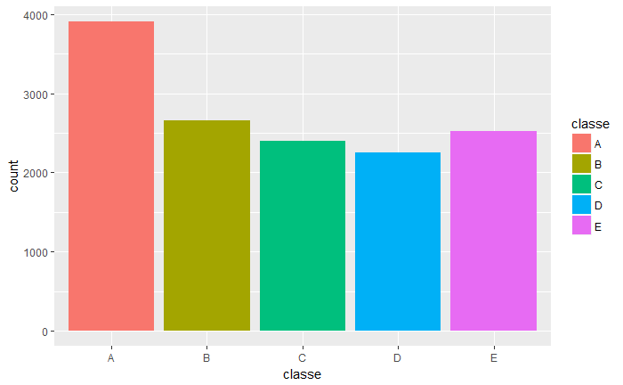

```r
qplot(x=classe, data= training, fill=classe)
```

- Plotting the features distributions

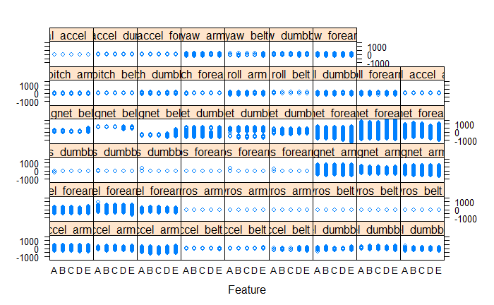

```r
featurePlot(training[,-outcomeIndex],training$classe,plot="strip")
```

- Plotting the correlation between features

[figure not shown]

```r
corrplot(cor(training[,-outcomeIndex]),order="hclust", method="number",addCoef.col="grey")
```

Even if there’s no high correlation in average, We see that there are some features which have a strong correlations between each other.

```r
StrongCorrelated <- findCorrelation(cor(training[,-outcomeIndex]), cutoff =.7)
```

```r
data.frame(names=colnames(training[,StrongCorrelated]),column.position=StrongCorrelated)
```

| names | column.position |
| --- | --- |
| accel_belt_z | 10 |
| roll_belt | 1 |
| accel_belt_y | 9 |
| total_accel_belt | 4 |
| yaw_belt | 3 |
| accel_dumbbell_z | 36 |
| accel_belt_x | 8 |
| pitch_belt | 2 |
| magnet_dumbbell_x | 37 |
| accel_dumbbell_y | 35 |

[output cut: 11 more lines]

So maybe, we’ll need to perform PCA processing in order to :

- reduce noise
- reduce number of predictors
- get high uncorrelated (orthogonal) predictors

### Preprocessing

```r
#perform PCA on the training and validation data set
pcaObj.1 <- preProcess(training[,-outcomeIndex], method = "pca", thresh = .95, pcaComp = 27)
training.pca <- predict(pcaObj.1, newdata=training[,-outcomeIndex])
training.pca$classe <- training$classe
pcaObj.2 <- preProcess(validation[,-outcomeIndex], method = "pca", thresh = .95, pcaComp = 27)
validation.pca <- predict(pcaObj.2, newdata=validation[,-outcomeIndex])
validation.pca$classe <- validation$classe
rm(pcaObj.1)
rm(pcaObj.2)
```

```r
dim(training.pca)
```

```
[1] 13737    28
```

```r
dim(validation.pca)
```

```
[1] 5885   28
```

```r
str(training.pca)
```

```
'data.frame':   13737 obs. of  28 variables:
 $ PC1   : num  4.59 4.56 4.58 4.57 4.58 ...
 $ PC2   : num  0.894 0.918 0.908 0.967 0.938 ...
 $ PC3   : num  -2.72 -2.72 -2.71 -2.68 -2.72 ...
 $ PC4   : num  1.19 1.18 1.18 1.17 1.18 ...
 $ PC5   : num  -1.3 -1.24 -1.25 -1.26 -1.25 ...
 $ PC6   : num  2.18 2.12 2.15 2.2 2.14 ...
 $ PC7   : num  -0.0157 0.0023 -0.026 -0.041 -0.0059 ...
 $ PC8   : num  -2.75 -2.78 -2.75 -2.75 -2.78 ...
 $ PC9   : num  0.109 0.106 0.13 0.082 0.11 ...
 $ PC10  : num  -0.344 -0.334 -0.342 -0.363 -0.316 ...
 $ PC11  : num  -0.607 -0.615 -0.621 -0.568 -0.601 ...
 $ PC12  : num  -0.792 -0.813 -0.839 -0.803 -0.847 ...
 $ PC13  : num  -2.94 -2.93 -2.93 -2.92 -2.94 ...
 $ PC14  : num  0.3 0.282 0.325 0.187 0.297 ...
 $ PC15  : num  -0.111 -0.169 -0.128 -0.154 -0.163 ...
 $ PC16  : num  0.841 0.859 0.846 0.796 0.849 ...
 $ PC17  : num  -0.601 -0.592 -0.562 -0.621 -0.573 ...
 $ PC18  : num  -0.424 -0.435 -0.421 -0.418 -0.434 ...
 $ PC19  : num  -1.32 -1.3 -1.3 -1.29 -1.29 ...
 $ PC20  : num  0.254 0.238 0.252 0.27 0.25 ...
 $ PC21  : num  -0.281 -0.315 -0.257 -0.284 -0.289 ...
 $ PC22  : num  0.344 0.384 0.369 0.394 0.395 ...
 $ PC23  : num  0.416 0.43 0.461 0.429 0.421 ...
 $ PC24  : num  -0.056776 0.009019 -0.011929 -0.000819 0.00623 ...
 $ PC25  : num  0.554 0.571 0.569 0.574 0.584 ...
 $ PC26  : num  -0.0471 -0.0288 -0.0393 -0.0252 -0.0167 ...
 $ PC27  : num  -0.907 -0.912 -0.897 -0.926 -0.883 ...
 $ classe: Factor w/ 5 levels "A","B","C","D",..: 1 1 1 1 1 1 1 1 1 1 ...
```

### Training data and model selection

- Random forest without the PCA processing performed on dataset

```r
#Fitting with random forest
ptm <- proc.time()
model.rf.1 <- train(classe~., data=training, method="rf", trControl = trainControl(method = "oob"), ntree = 250)
proc.time() - ptm
```

- Random forest with the PCA processing performed on dataset

```r
#Fitting with random forest
ptm <- proc.time()
model.rf.2 <- train(classe~., data=training.pca, method="rf", trControl = trainControl(method = "oob"), ntree = 250)
proc.time() - ptm
```

```r
model.rf.1$finalModel
```

```
Call:
 randomForest(x = x, y = y, ntree = 250, mtry = param$mtry)
               Type of random forest: classification
                     Number of trees: 250
No. of variables tried at each split: 2

        OOB estimate of  error rate: 0.79%
Confusion matrix:
     A    B    C    D    E class.error
A 3902    3    0    0    1 0.001024066
B   19 2626   13    0    0 0.012039127
C    0   21 2371    4    0 0.010434057
D    0    0   37 2211    4 0.018206039
E    0    0    0    7 2518 0.002772277
```

```r
model.rf.2$finalModel
```

```
Call:
 randomForest(x = x, y = y, ntree = 250, mtry = param$mtry)
               Type of random forest: classification
                     Number of trees: 250
No. of variables tried at each split: 2

        OOB estimate of  error rate: 2.69%
Confusion matrix:
     A    B    C    D    E class.error
A 3870   11   14    7    4  0.00921659
B   55 2560   38    2    3  0.03686983
C    7   41 2322   22    4  0.03088481
D    5    2   94 2144    7  0.04795737
E    3   21   15   14 2472  0.02099010
```

### Evaluation on validation set and out-of-sample error

```r
pred.1 <- predict(model.rf.1, newdata = validation)
confusionMatrix(pred.1, validation$classe)
```

```
Confusion Matrix and Statistics

          Reference
Prediction    A    B    C    D    E
         A 1673   11    0    0    0
         B    1 1123   13    0    0
         C    0    4 1008   26    0
         D    0    0    5  937    4
         E    0    1    0    1 1078

Overall Statistics

               Accuracy : 0.9888
                 95% CI : (0.9858, 0.9913)
    No Information Rate : 0.2845
    P-Value [Acc > NIR] : < 2.2e-16

                  Kappa : 0.9858
 Mcnemar's Test P-Value : NA

Statistics by Class:

                     Class: A Class: B Class: C Class: D Class: E
Sensitivity            0.9994   0.9860   0.9825   0.9720   0.9963
Specificity            0.9974   0.9971   0.9938   0.9982   0.9996
Pos Pred Value         0.9935   0.9877   0.9711   0.9905   0.9981
Neg Pred Value         0.9998   0.9966   0.9963   0.9945   0.9992
Prevalence             0.2845   0.1935   0.1743   0.1638   0.1839
Detection Rate         0.2843   0.1908   0.1713   0.1592   0.1832
Detection Prevalence   0.2862   0.1932   0.1764   0.1607   0.1835
Balanced Accuracy      0.9984   0.9915   0.9881   0.9851   0.9979
```

```r
pred.2 <- predict(model.rf.2, newdata = validation.pca)
confusionMatrix(pred.2, validation.pca$classe)
```

```
Confusion Matrix and Statistics

          Reference
Prediction   A   B   C   D   E
         A 374 209 270 297 218
         B 309 248 275 231 252
         C 250  30 100  63  42
         D  29  55  31  24  54
         E 712 597 350 349 516

Overall Statistics

               Accuracy : 0.2144
                 95% CI : (0.204, 0.2252)
    No Information Rate : 0.2845
    P-Value [Acc > NIR] : 1

                  Kappa : 0.0082
 Mcnemar's Test P-Value : <2e-16

Statistics by Class:

                     Class: A Class: B Class: C Class: D Class: E
Sensitivity           0.22342  0.21773  0.09747 0.024896  0.47689
Specificity           0.76395  0.77518  0.92077 0.965657  0.58193
Pos Pred Value        0.27339  0.18859  0.20619 0.124352  0.20444
Neg Pred Value        0.71220  0.80503  0.82852 0.834856  0.83160
Prevalence            0.28445  0.19354  0.17434 0.163806  0.18386
Detection Rate        0.06355  0.04214  0.01699 0.004078  0.08768
Detection Prevalence  0.23246  0.22345  0.08241 0.032795  0.42889
Balanced Accuracy     0.49368  0.49646  0.50912 0.495277  0.52941
```

We can see that the best accurracy is the one from the first model without PCA processing. So we will keep this model to make predictions on our test set.

Let’s make in-depth analysis of the choosen model:

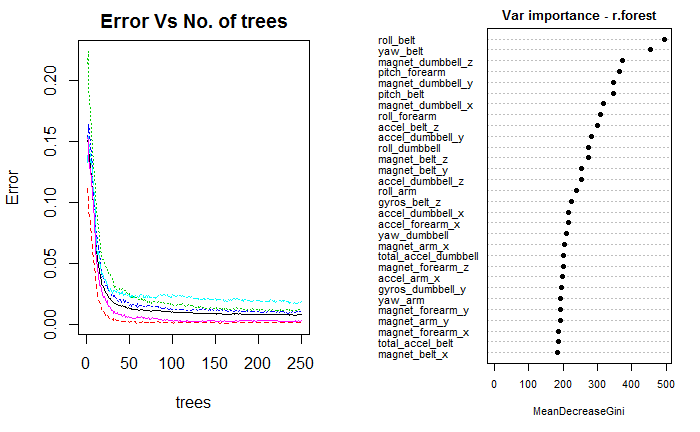

```r
par(mfrow=c(1,2))
plot(model.rf.1$finalModel,cex=0.7, pch=16, main="Error Vs No. of trees")
varImpPlot(model.rf.1$finalModel, cex=0.7, pch=16, main="Var importance - r.forest")
```

## Prediction on the testing data

```r
predictions <- predict(model.rf.1, newdata=testing)
predictions
```

```
 [1] B A B A A E D B A A B C B A E E A B B B
Levels: A B C D E
```